# TRABAJO PRÁCTICO 02: Preprocesamiento de datos -Análisis, Limpieza, Transformación e Integración-

juan-natello

8/10/2020

#### Limpieza de datos: Datos Faltantes

- 1. Datos Faltantes: Se cuenta con el dataset encuesta_universitaria.csv, el cual posee valores faltantes para la variable tiempo_traslado. Aplique los siguientes métodos a efectos de reemplazar esos valores:
  - 1. Verifique cual es la proporción de valores faltantes respecto a la cantidad total de instancias del dataset.  
       RESPUESTA: Para este problema,usamos la funcion sum(is.na(encuesta_universitaria$‘Tiempo_Traslado’)) para ver la cantidad total de faltantes.

```
## [1] "Cantidad de Faltantes Tiempo Traslado:  863"
```

```
## [1] "Dimensiones DataSet:  194403  datos"
```

```
## [1] "PROPORCION DE FALTANTES:  0.443923190485744 %"
```

Esto nos dice que hay 5891 filas (sin incluir las cabeceras) por 33 columnas, esto es igual a 194403 datos de los cuales, 863 datos son faltantes, en cuestiones de proporcion, estos representan aproximadamente el 0.44 %.

- 2. Genere un nuevo atributo utilizando solo los registros con valores observados para el atributo.

```r
  naOmit_tiempo_tralado <- na.omit(encuesta_universitaria$Tiempo_Traslado)
  str(naOmit_tiempo_tralado)
```

```
##  num [1:5028] 40 90 30 20 40 30 120 30 50 60 ...
##  - attr(*, "na.action")= 'omit' int [1:863] 6 7 9 13 15 28 32 33 40 46 ...
```

- 3. Genere un nuevo atributo en el que sustituya los valores faltantes por la media encontrada para el atributo

```r
tiempo_traslado <- encuesta_universitaria$Tiempo_Traslado
tiempo_traslado[is.na(tiempo_traslado)]=mean(tiempo_traslado, na.rm = TRUE)
str(tiempo_traslado)
```

```
##  num [1:5891] 40 90 30 20 40 ...
```

```r
tiempo_traslado.mean = tiempo_traslado
```

- 4. Genere un nuevo atributo en el que sustituya los valores faltantes de acuerdo al método de “hot deck imputation”.

```r
 df_aux <- hotdeck(encuesta_universitaria, variable = "Tiempo_Traslado")
 tiempo_traslado.hotdeck <- df_aux$Tiempo_Traslado
 sum(is.na(tiempo_traslado.hotdeck))
```

```
## [1] 0
```

- 5. Analice los resultados encontrados a partir de la aplicación de los métodos anteriores. Compare los mismos realizando gráficos sobre los valores resultantes en cada caso.

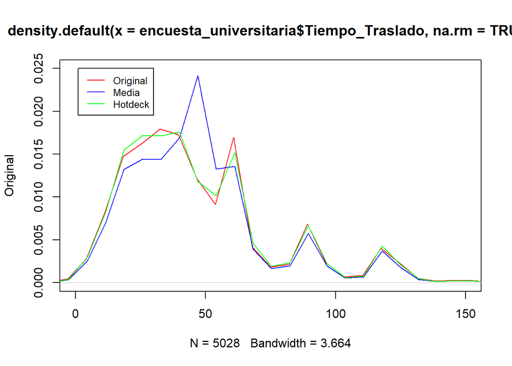

- Como se puede observar la imputacion por media es la que mas se diferencia de la distribucion original de los datos, debido a que se esta llenado los valores faltantes con el valor de la media, entonces lo que hace es aumentar el valor donde tengo ubicada la media y me estira la proporcion alrededor de la misma. En cambio la distribucion sobre Hotdeck es la que mas respeta la distribucion normal de la variable.

#### Limpieza de datos: Manejo de Ruido

- 2.Para el dataset anterior, avance sobre las siguientes operaciones para los atributos numéricos (cuantitativos continuos):

Las variables con atributos numericos son:

- Carrera
- Sede
- Tiempo Traslado
- Cantidad Grupo Familiar
- 1. Verifique en primer lugar la distribución de los datos, utilice algún método gráfico para esto.

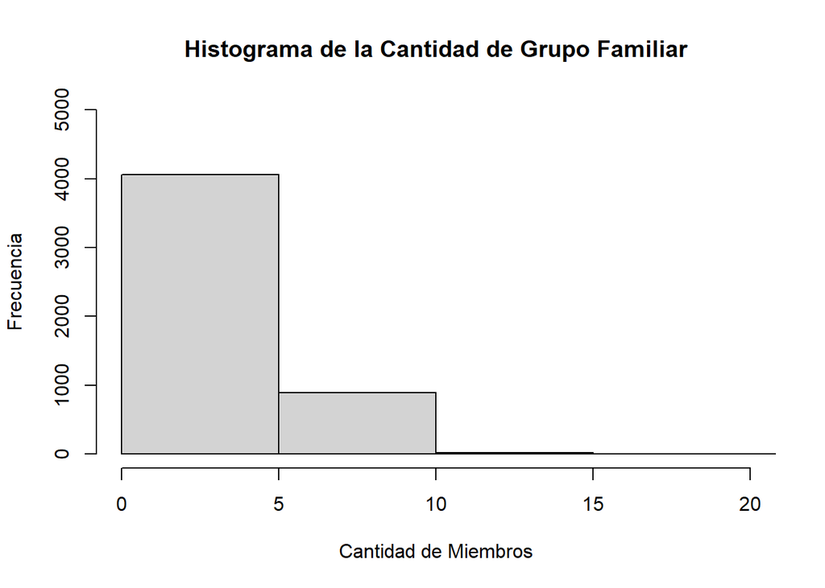

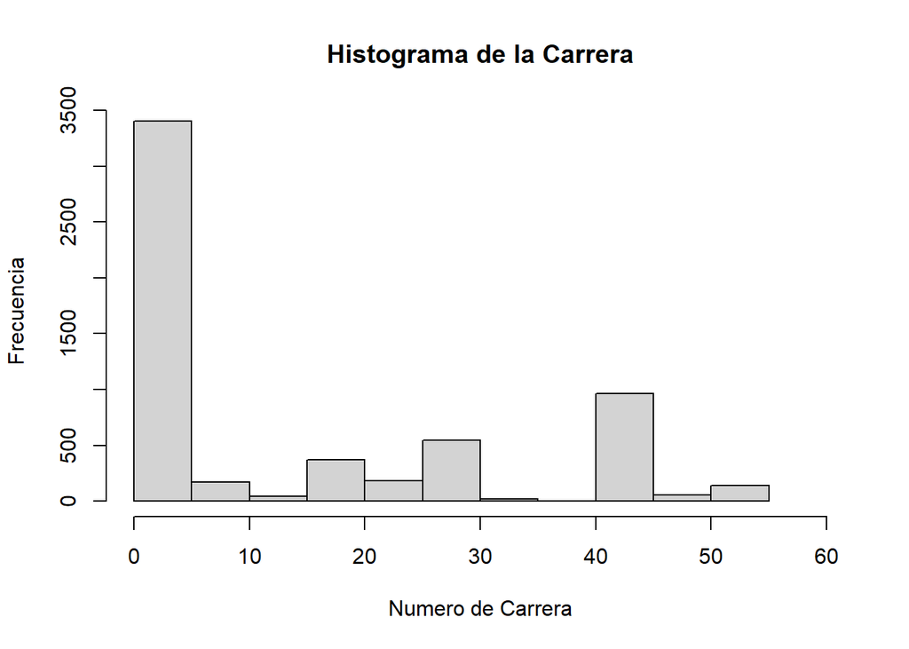

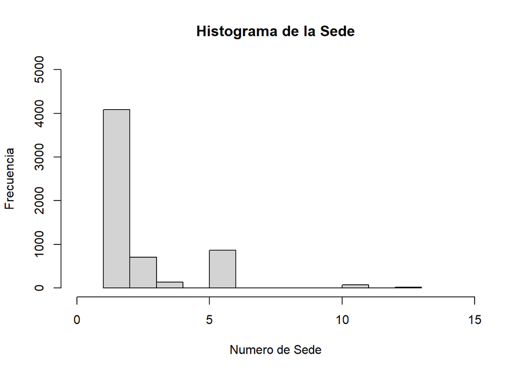

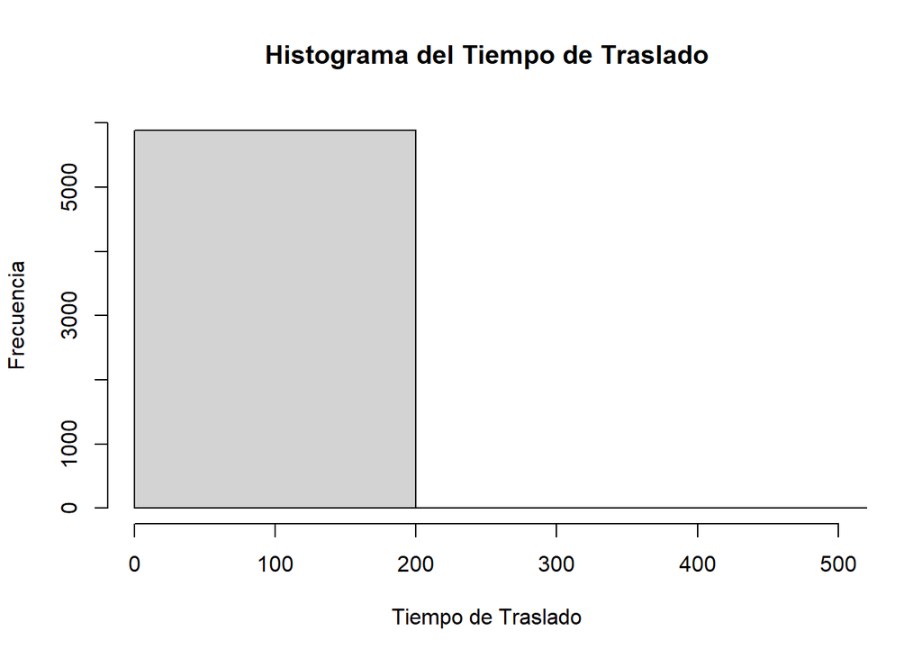

Observando la distribucion de los datos: * Cantidad de Grupo familiar: se puede observar el mayor porcentaje va entre 0 y 5 miembros. * Carrera: se puede decir que el numero de carrera mas elegida esta entre la numero 0 y 5. * Sede: La sede 1 es la mas elegida. * Tiempo de Traslado: La mayor parte tarda entre 0 y 200.

- 2. Realice un suavizado utilizando binning por frecuencias iguales (con 5 bins) y estime el valor del bin por el cálculo de medias.

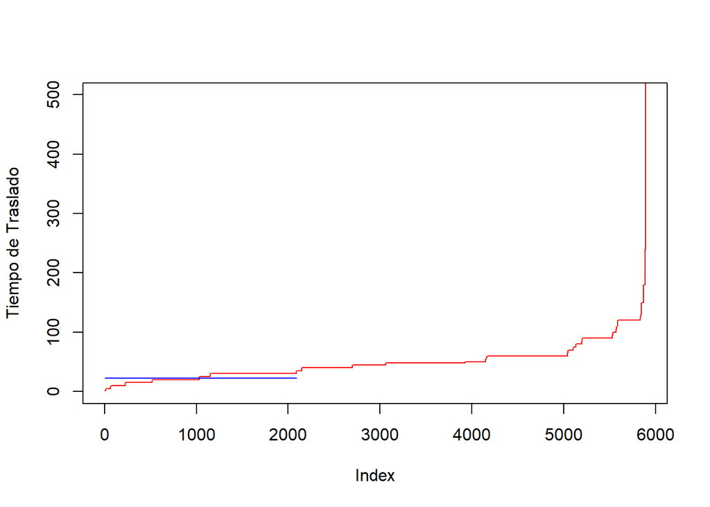

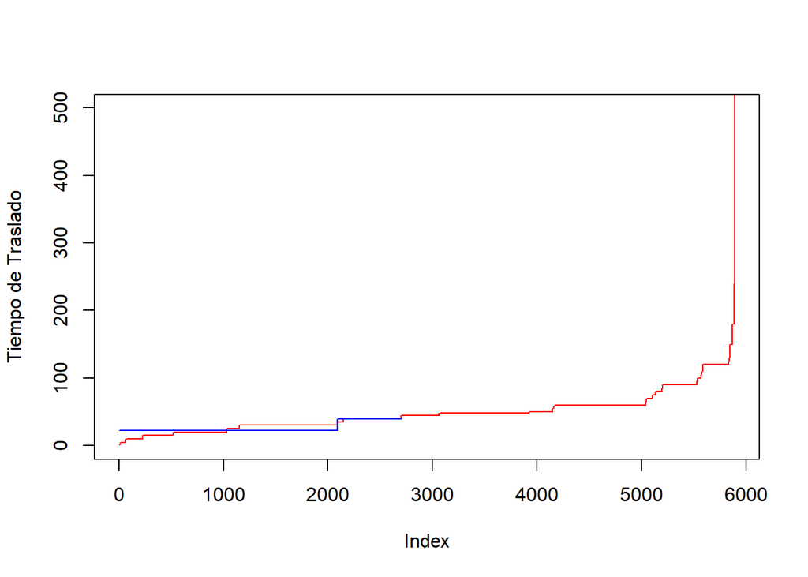

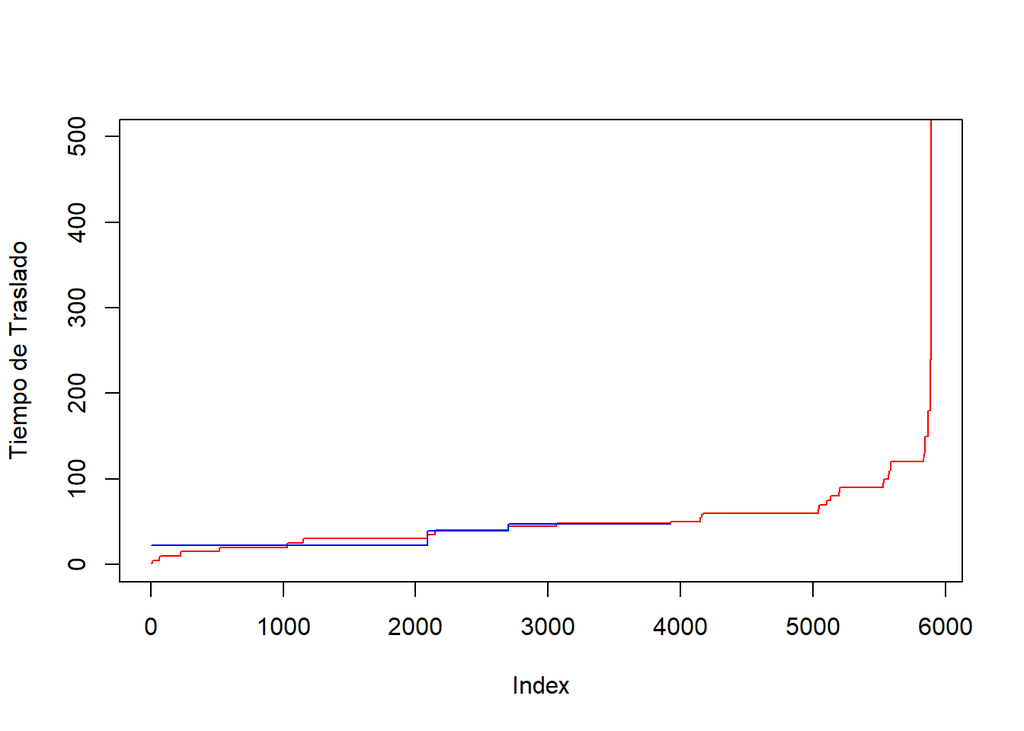

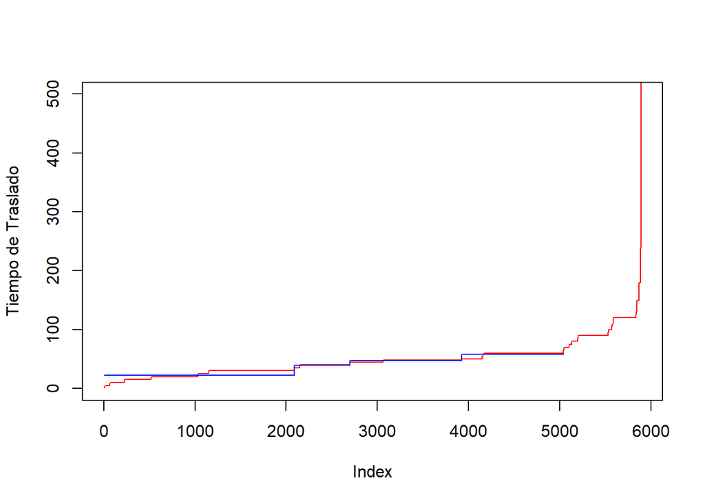

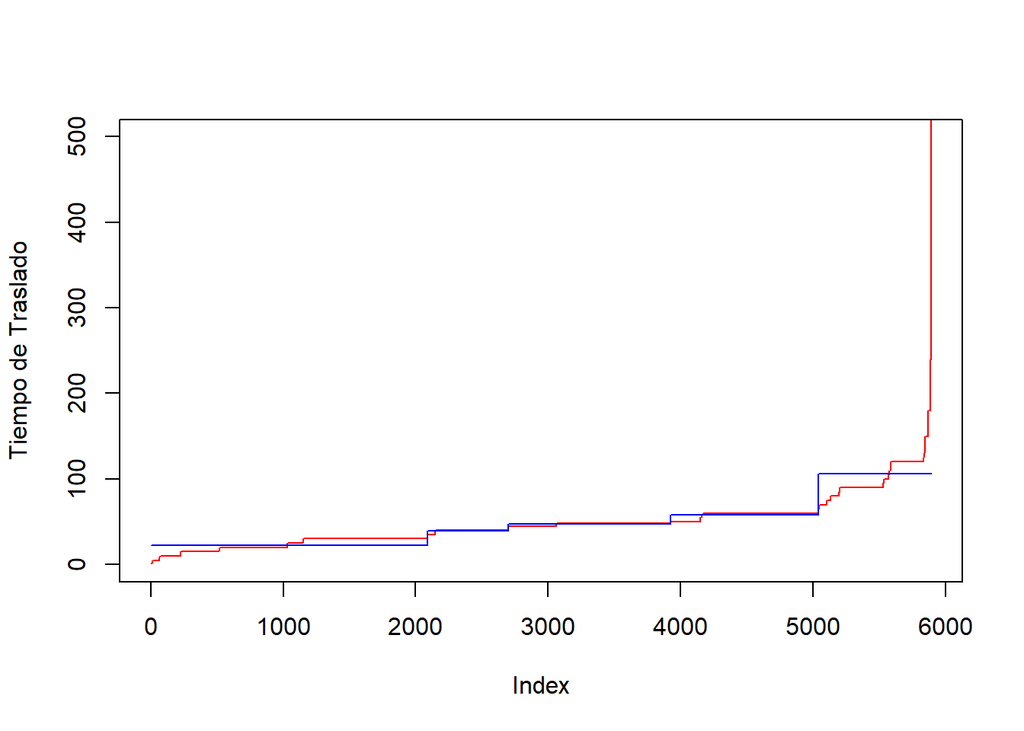

- 3. Ahora, realice el suavizado por anchos iguales (con 5 bins) y compare los resultados gráficamente.

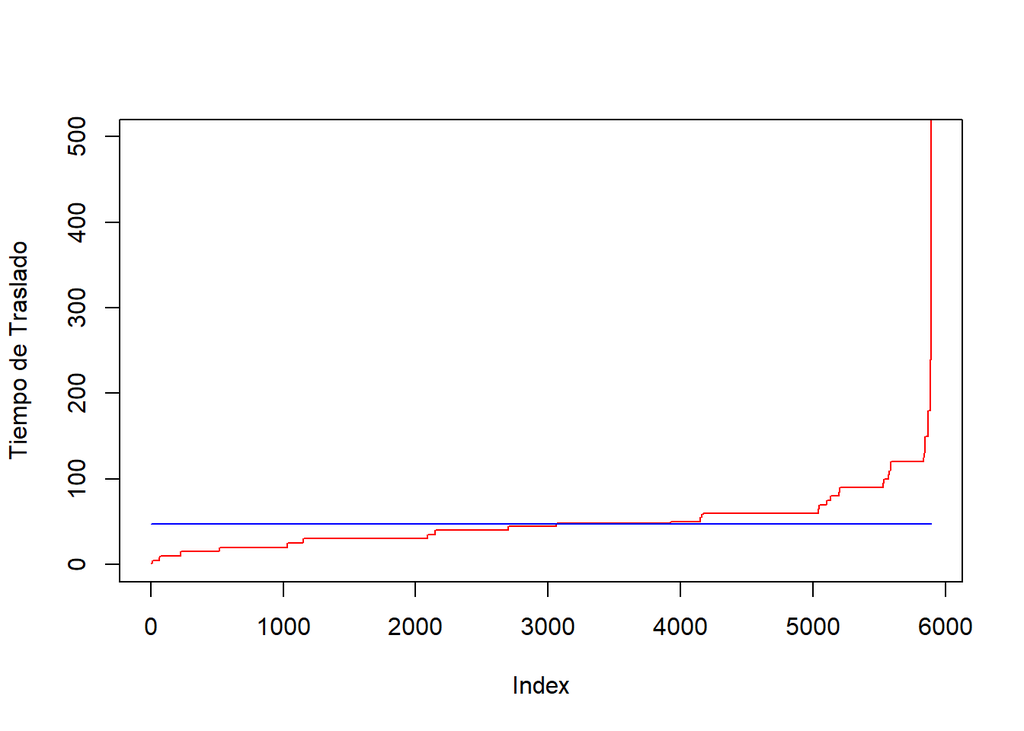

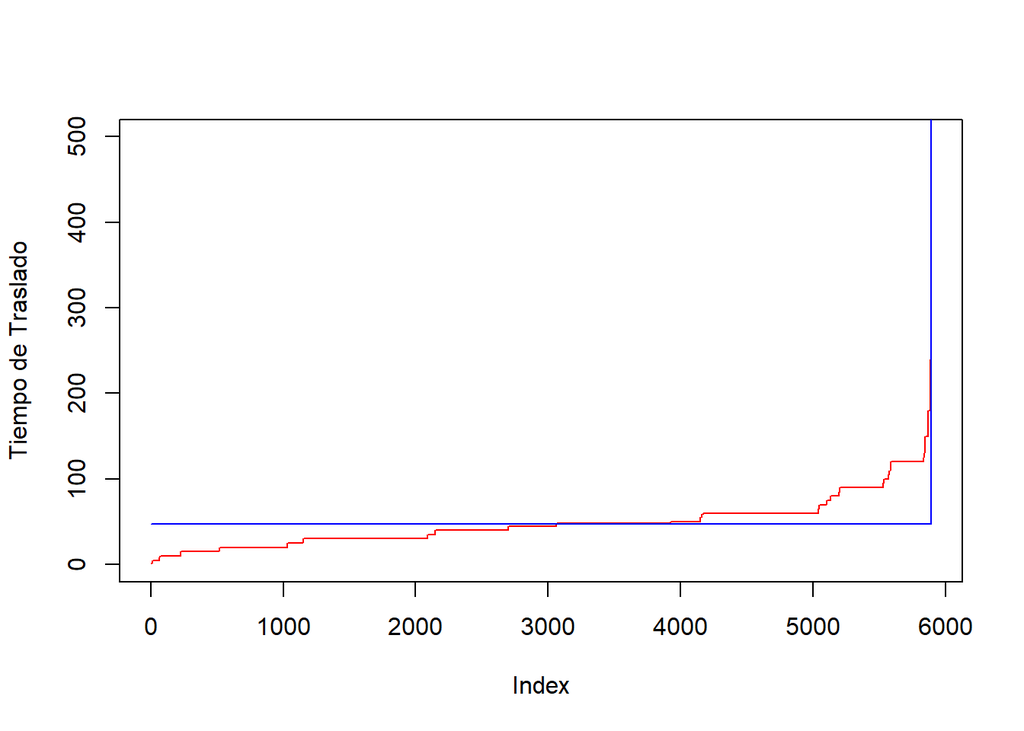

Se puede observar que el suevizado por igual frecuencia respeta mas la distribucion de los datos originales.

#### Limpieza de datos: Manejo de Ruido. Ahora, trabaje sobre el mismo atributo del dataset original con las siguientes consignas: